# Time_Series_Project_KAWA

## Fitting models

```r
model_200100 <- sarima(d12_temp,2,0,0,1,0,0,12) # sarima(2,0,0)(1,0,0)[12]
```

```
## <><><><><><><><><><><><><><>
##
## Coefficients:
##       Estimate     SE  t.value p.value
## ar1     0.1825 0.0314   5.8127  0.0000
## ar2     0.0768 0.0315   2.4373  0.0150
## sar1   -0.4717 0.0280 -16.8330  0.0000
## xmean   0.0623 0.0690   0.9034  0.3665
##
## sigma^2 estimated as 5.665529 on 1004 degrees of freedom
##
## AIC = 4.585245  AICc = 4.585284  BIC = 4.609628
##
```

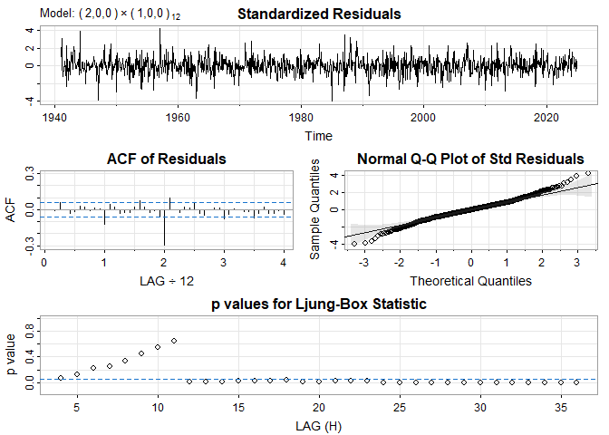

```r
model_201100 <- sarima(d12_temp,2,0,1,1,0,0,12) # sarima(2,0,1)(1,0,0)[12]
```

```
## <><><><><><><><><><><><><><>
##
## Coefficients:
##       Estimate     SE  t.value p.value
## ar1     0.5322 0.2360   2.2552  0.0243
## ar2     0.0130 0.0623   0.2093  0.8343
## ma1    -0.3535 0.2343  -1.5090  0.1316
## sar1   -0.4711 0.0280 -16.7994  0.0000
## xmean   0.0627 0.0726   0.8632  0.3882
##
## sigma^2 estimated as 5.655024 on 1003 degrees of freedom
##
## AIC = 4.585368  AICc = 4.585428  BIC = 4.614629
##
```

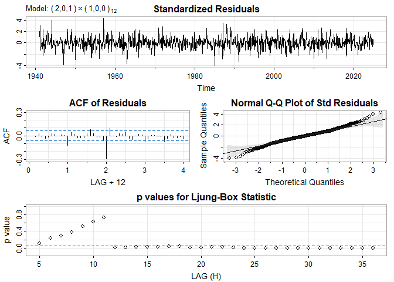

```r
model_001001 <- sarima(d12_temp, 0,0,1,0,0,1,12) # sarima(0,0,1)(0,0,1)[12]
```

```
## <><><><><><><><><><><><><><>
##
## Coefficients:
##       Estimate     SE  t.value p.value
## ma1     0.2157 0.0287   7.5059       0
## sma1   -0.9512 0.0144 -66.2298       0
## xmean   0.0309 0.0051   6.0150       0
##
## sigma^2 estimated as 4.083189 on 1005 degrees of freedom
##
## AIC = 4.280736  AICc = 4.28076  BIC = 4.300243
##
```

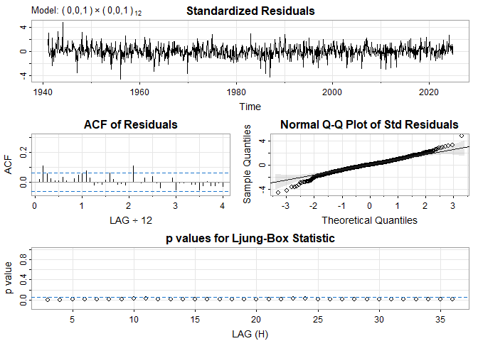

```r
model_001001 <- sarima(d12_temp, 1,0,0,0,0,1,12) # sarima(1,0,0)(0,0,1)[12]
```

```
## <><><><><><><><><><><><><><>
##
## Coefficients:
##       Estimate     SE  t.value p.value
## ar1     0.2484 0.0310   8.0190       0
## sma1   -0.9542 0.0143 -66.6939       0
## xmean   0.0309 0.0054   5.7414       0
##
## sigma^2 estimated as 4.043796 on 1005 degrees of freedom
##
## AIC = 4.271777  AICc = 4.271801  BIC = 4.291284
##
```

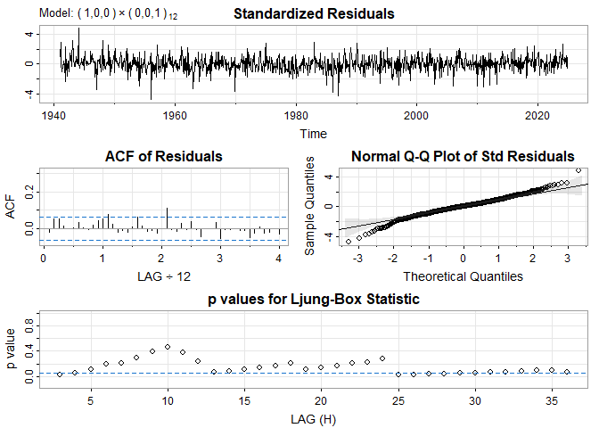

Models above do not satisfy the assumptions on the residuals - see Ljung-Box Q test.

```r
model_101101 <- sarima(d12_temp, 1,0,1,1,0,1,12) # sarima(1,0,1)(1,0,1)[12]
```

```
## <><><><><><><><><><><><><><>
##
## Coefficients:
##       Estimate     SE  t.value p.value
## ar1     0.5516 0.1029   5.3582  0.0000
## ma1    -0.3291 0.1166  -2.8223  0.0049
## sar1    0.0495 0.0338   1.4637  0.1436
## sma1   -0.9603 0.0140 -68.4656  0.0000
## xmean   0.0310 0.0058   5.3242  0.0000
##
## sigma^2 estimated as 4.008399 on 1003 degrees of freedom
##
## AIC = 4.267495  AICc = 4.267555  BIC = 4.296755
##
```

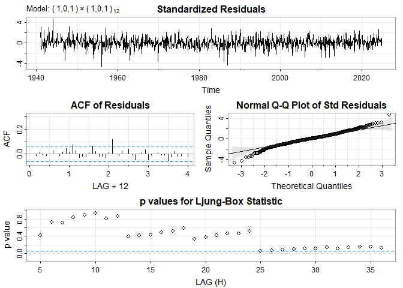

Residuals also do not satisfy assumtions, see:

```r
rr <- model_101101$fit$residuals
Box.test(rr, lag = 25, type = "Ljung-Box", fitdf = 4)
```

```
##
##  Box-Ljung test
##
## data:  rr
## X-squared = 32.806, df = 21, p-value = 0.04842
```

At lag=25 we obtain p-value smaller than 0.05.

```r
model_201101 <- sarima(d12_temp,2,0,1,1,0,1,12) # sarima(2,0,1)(1,0,1)[12]
```

```
## <><><><><><><><><><><><><><>
##
## Coefficients:
##       Estimate     SE  t.value p.value
## ar1     0.7042 0.3573   1.9710  0.0490
## ar2    -0.0454 0.1066  -0.4256  0.6705
## ma1    -0.4792 0.3550  -1.3500  0.1773
## sar1    0.0491 0.0338   1.4499  0.1474
## sma1   -0.9598 0.0140 -68.4492  0.0000
## xmean   0.0311 0.0060   5.2006  0.0000
##
## sigma^2 estimated as 4.008044 on 1002 degrees of freedom
##
## AIC = 4.269269  AICc = 4.269352  BIC = 4.303406
##
```

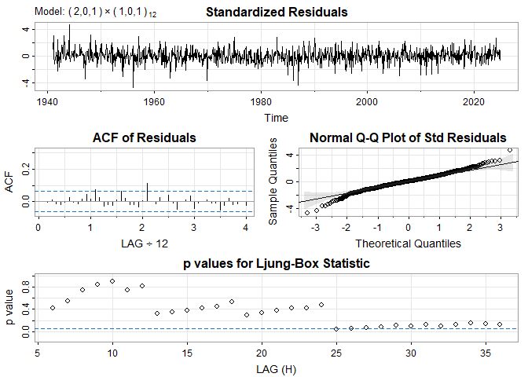

```r
rr <- model_201101$fit$residuals
p_values <- sapply(10:30, function(k) {
  test <- Box.test(rr, lag = k, type = "Ljung-Box", fitdf = 4)
  return(c("Lag" = k, "p-value" = round(test$p.value, 4)))
})
t(p_values)
```

```
##       Lag p-value
##  [1,]  10  0.9538
##  [2,]  11  0.8354
##  [3,]  12  0.8845
##  [4,]  13  0.4097
##  [5,]  14  0.4458
##  [6,]  15  0.4606
##  [7,]  16  0.5110
##  [8,]  17  0.5381
##  [9,]  18  0.6078
## [10,]  19  0.3604
## [11,]  20  0.4052
## [12,]  21  0.4463
## [13,]  22  0.4855
## [14,]  23  0.4842
## [15,]  24  0.5454
## [16,]  25  0.0558
## [17,]  26  0.0739
## [18,]  27  0.0907
## [19,]  28  0.1027
## [20,]  29  0.1294
## [21,]  30  0.1206
```

Residuals satisfy assumptions.

```r
auto_noise <- auto.arima(d12_temp, seasonal = TRUE)
summary(auto_noise)
```

```
## Series: d12_temp
## ARIMA(2,0,1)(1,0,0)[12] with non-zero mean
##
## Coefficients:
##          ar1     ar2      ma1     sar1    mean
##       0.5322  0.0130  -0.3535  -0.4711  0.0627
## s.e.  0.2360  0.0623   0.2343   0.0280  0.0726
##
## sigma^2 = 5.683:  log likelihood = -2305.03
## AIC=4622.05   AICc=4622.14   BIC=4651.55
##
## Training set error measures:
##                        ME    RMSE      MAE      MPE     MAPE      MASE
## Training set 0.0008409097 2.37803 1.793578 96.64639 280.7723 0.5140894
##                     ACF1
## Training set 5.16774e-05
```

Function auto.arima proposed ARIMA(2,0,1)(1,0,0)[12] model, however we can see that in this model residuals do not satisfy assumtions.

We conclude that model ARIMA(2,0,1)(1,0,1)[12] is the most suitable, so this is our final model.